# p8105_hw1_yz4982

Yuanyuan Zhang

## Promblem 1

### Early january weather datase

```r
# load the moderndive package
library(moderndive)

# Load the early_january_weather dataset
data("early_january_weather")

# Show the first 6 rows
head(early_january_weather)
```

```
## # A tibble: 6 × 15
##   origin  year month   day  hour  temp  dewp humid wind_dir wind_speed wind_gust
##   <chr>  <int> <int> <int> <int> <dbl> <dbl> <dbl>    <dbl>      <dbl>     <dbl>
## 1 EWR     2013     1     1     1  39.0  26.1  59.4      270      10.4         NA
## 2 EWR     2013     1     1     2  39.0  27.0  61.6      250       8.06        NA
## 3 EWR     2013     1     1     3  39.0  28.0  64.4      240      11.5         NA
## 4 EWR     2013     1     1     4  39.9  28.0  62.2      250      12.7         NA
## 5 EWR     2013     1     1     5  39.0  28.0  64.4      260      12.7         NA
## 6 EWR     2013     1     1     6  37.9  28.0  67.2      240      11.5         NA
## # ℹ 4 more variables: precip <dbl>, pressure <dbl>, visib <dbl>,
## #   time_hour <dttm>
```

```r
# Show dataset structure with variable types
dplyr::glimpse(early_january_weather)
```

```
## Rows: 358
## Columns: 15
## $ origin     <chr> "EWR", "EWR", "EWR", "EWR", "EWR", "EWR", "EWR", "EWR", "EW…
## $ year       <int> 2013, 2013, 2013, 2013, 2013, 2013, 2013, 2013, 2013, 2013,…
## $ month      <int> 1, 1, 1, 1, 1, 1, 1, 1, 1, 1, 1, 1, 1, 1, 1, 1, 1, 1, 1, 1,…
## $ day        <int> 1, 1, 1, 1, 1, 1, 1, 1, 1, 1, 1, 1, 1, 1, 1, 1, 1, 1, 1, 1,…
## $ hour       <int> 1, 2, 3, 4, 5, 6, 7, 8, 9, 10, 11, 13, 14, 15, 16, 17, 18, …
## $ temp       <dbl> 39.02, 39.02, 39.02, 39.92, 39.02, 37.94, 39.02, 39.92, 39.…
## $ dewp       <dbl> 26.06, 26.96, 28.04, 28.04, 28.04, 28.04, 28.04, 28.04, 28.…
## $ humid      <dbl> 59.37, 61.63, 64.43, 62.21, 64.43, 67.21, 64.43, 62.21, 62.…
## $ wind_dir   <dbl> 270, 250, 240, 250, 260, 240, 240, 250, 260, 260, 260, 330,…
## $ wind_speed <dbl> 10.35702, 8.05546, 11.50780, 12.65858, 12.65858, 11.50780, …
## $ wind_gust  <dbl> NA, NA, NA, NA, NA, NA, NA, NA, NA, NA, NA, NA, NA, NA, 20.…
## $ precip     <dbl> 0, 0, 0, 0, 0, 0, 0, 0, 0, 0, 0, 0, 0, 0, 0, 0, 0, 0, 0, 0,…
## $ pressure   <dbl> 1012.0, 1012.3, 1012.5, 1012.2, 1011.9, 1012.4, 1012.2, 101…
## $ visib      <dbl> 10, 10, 10, 10, 10, 10, 10, 10, 10, 10, 10, 10, 10, 10, 10,…
## $ time_hour  <dttm> 2013-01-01 01:00:00, 2013-01-01 02:00:00, 2013-01-01 03:00…
```

The variables in this dataset are:  
origin, year, month, day, hour, temp, dewp, humid, wind_dir, wind_speed, wind_gust, precip, pressure, visib, time_hour.

The dataset has 358 rows and 15 columns.

The average temperature is 39.6 °F.

### Scatterplot of temperature vs time

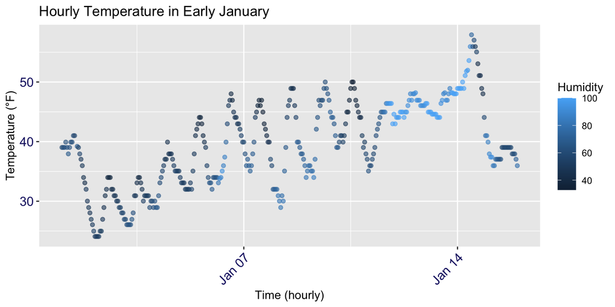

```r
library(ggplot2)

# Scatterplot: temp vs time_hour, colored by humidity
p1 <- ggplot(early_january_weather, aes(x = time_hour, y = temp, color = humid)) +
  geom_point(alpha = 0.6) +
  labs(
    title = "Hourly Temperature in Early January",
    x = "Time (hourly)",
    y = "Temperature (°F)",
    color = "Humidity"
  ) +
  theme(
  # X-axis label font size, rotation angle
  axis.text.x = element_text(size = 12, angle = 45, hjust = 1, color = "midnightblue"),
  # Y-axis label color
  axis.text.y = element_text(size = 12, color ='midnightblue')
)

p1
```

The data show strong daily cycles: temperatures rise during the day and fall at night. The Clear upward trend in temperatures across the two weeks of January

There is some day-to-day variation early January starts cooler in the 20–30 °F range, while later days show warmer averages 40–50 °F range.

## Promblem 2

### Create a data frame

```r
library(tidyverse)
set.seed(123)

# a random sample of size 10 from a standard Normal distribution
x <- rnorm(10)

# a logical vector indicating whether elements of the sample > 0
logical_vector <- x > 0

# a character vector of length 10
chars <- sample(letters, 10)

# a factor vector of length 10, with 3 different factor “levels"
factor_vector <- factor(sample(c("sad","peaceful","happy"), 10, replace = TRUE))

# data frame

df <- tibble(x, logical_vector, chars, factor_vector )
df
```

```
## # A tibble: 10 × 4
##          x logical_vector chars factor_vector
##      <dbl> <lgl>          <chr> <fct>
##  1 -0.560  FALSE          y     sad
##  2 -0.230  FALSE          z     happy
##  3  1.56   TRUE           i     happy
##  4  0.0705 TRUE           c     sad
##  5  0.129  TRUE           h     happy
##  6  1.72   TRUE           g     peaceful
##  7  0.461  TRUE           j     sad
##  8 -1.27   FALSE          x     happy
##  9 -0.687  FALSE          d     sad
## 10 -0.446  FALSE          n     sad
```

```r
mean(df %>% pull(x))       # number exist
```

```
## [1] 0.07462564
```

```r
mean(df %>% pull(logical_vector))  # number exist
```

```
## [1] 0.5
```

```r
mean(df %>% pull(chars))   # NA (Warning message)
```

```
## [1] NA
```

```r
mean(df %>% pull(factor_vector))     # NA (Warning message)
```

```
## Warning in mean.default(df %>% pull(factor_vector)): argument is not numeric or
## logical: returning NA
```

```
## [1] NA
```

The numeric (x) can be mean() directly.

The character and factor columns cannot be averaged directly mean() requires a numeric or logical vector, or it will report an error or return NA with a warning.

### Convert variables from one type to another

```r
# logical -> numeric：TRUE -> 1, FALSE -> 0 [ 0 0 1 1 1 1 1 0 0 0]
as.numeric(df$logical_vector)
```

```
##  [1] 0 0 1 1 1 1 1 0 0 0
```

```r
# char -> numeric：Warning message [NAs introduced by coercion]
as.numeric(df$chars)
```

```
## Warning: NAs introduced by coercion
```

```
##  [1] NA NA NA NA NA NA NA NA NA NA
```

```r
# factor vector -> numeric: [3 1 1 3 1 2 3 1 3 3]
as.numeric(df$factor_vector)
```

```
##  [1] 3 1 1 3 1 2 3 1 3 3
```

When logical values are converted to numbers, true becomes 1 and false becomes 0. Thus, the mean value gives the ratio of the three. When characters are converted, r cannot interpret letters as numbers, so it returns NA with a warning. when factors are converted, r returns internal integer codes based on their order rather than on the level of the label, and these numbers are usually not interpreted in a meaningful way.

The mean works for numeric and logical variables because they can be represented as numbers, but it fails for characters and factors because their values do not have inherent numeric meaning.